# TSHW4 Draft

Blue Team 16

# Setup

```r
# Reading in the data
energy <- read.csv("data/hrl_load_metered.csv")
energyTest <- read.csv("data/hrl_load_metered - test1.csv")

# Duplicate Spring removal
energy <- energy %>% group_by(datetime_beginning_ept) %>%
  summarize(mw = mean(mw, na.rm = T),.groups = "drop") %>%
  rename("time" = datetime_beginning_ept)

energyTest <- energyTest %>%
  group_by(datetime_beginning_ept) %>%
  summarize(mw = mean(mw, na.rm = T),.groups = "drop") %>%
  rename("time" = datetime_beginning_ept)

# Fixing time values
energy$time <- as.POSIXct(energy$time,format = "%m/%d/%y %H:%M",tz = "America/New_York")

energyTest$time <- as.POSIXct(energyTest$time,format = "%m/%d/%y %H:%M",tz = "America/New_York")

# Converting to Tsibble and filling gaps

energy <- energy %>% as_tsibble(index = time) %>% fill_gaps()

energyTest <- energyTest %>% as_tsibble(index = time) %>% fill_gaps()

# Imputing fall
energy <- energy %>% na_interpolation(option = "spline")

energyTest <- energyTest %>% na_interpolation(option = "spline")

## DUMMY VARIABLE MODEL HELPERS

# Add set indicator for separating
energy <- energy %>% mutate(set = "train")
energyTest <- energyTest %>% mutate(set = "test")

# Add all helper variables and combine sets to ensure factor levels are present throughout
energyCombined <- bind_rows(energy,energyTest) %>%
  mutate(month = factor(month(time))) %>%
  mutate(hour = factor(hour(time))) %>%
  mutate(dayOfWeek = factor(wday(time))) %>%
  mutate(year = factor(year(time))) %>%
  mutate(day = factor(day(time)))

# Separate sets back out
energy <- energyCombined %>% filter(set == "train")
energyTest <- energyCombined %>% filter(set == "test")
```

# Investigating Series

## Stationarity

```r
gg_tsdisplay(energy[1:15000,])
```

```
## Plot variable not specified, automatically selected `y = mw`
```

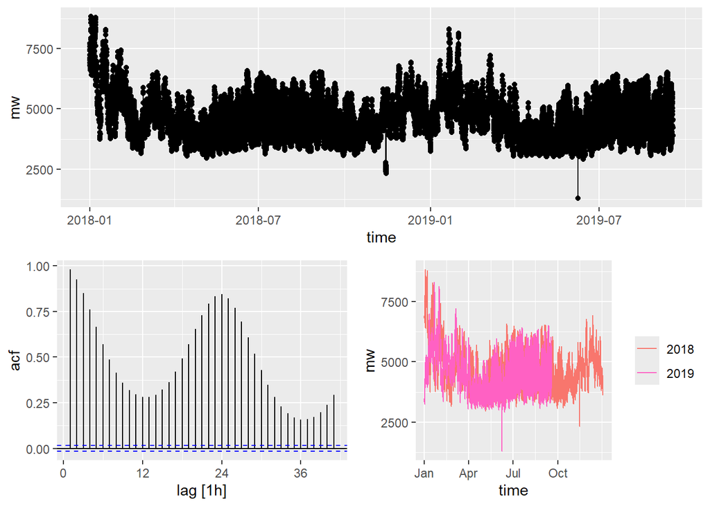

Very doubtful of stationary, this is real data

```r
ndiffs(energy$mw)
```

```
## [1] 1
```

All models perform better with differences, and statistical tests indicate we should be taking a first difference. All plots and models are on differenced data going forward.

## Selecting Lags

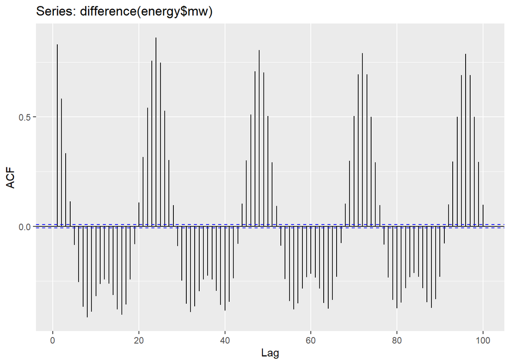

```r
ggAcf(difference(energy$mw),lag.max = 100)
```

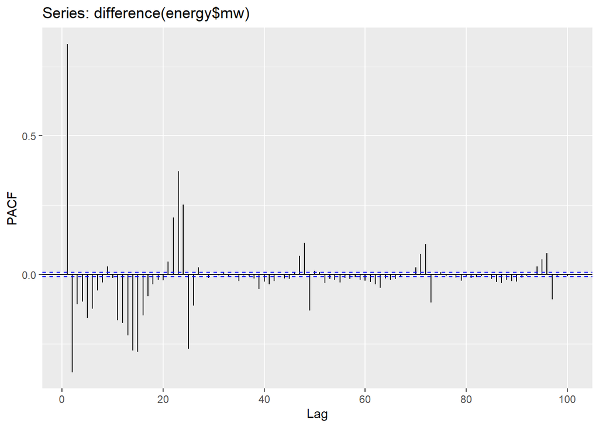

```r
ggPacf(difference(energy$mw),lag.max = 100)
```

PACF:Seeing exponential decrease in PACF aside from two spikes at lags 1, 2, and 24. Thinking p = 2, and P = 1 for a Basic Arima model.

ACF: Large spikes throughout. Hard to tell with such complex seasonality. Would say q = 3 to account for the large spikes at 1,2,3, and Q = 7, because looking back any farther than a week feels like it wouldnt be sound.

# Exponential Smoothing Models

```r
# Create all Exponential Smoothing models
etsFit <- energy %>% mutate(mw = difference(mw))
  model(
    `SES` = ETS(mw ~ error("A") + trend("N") + season("N")),
    `Linear` = ETS(mw ~ error("A") + trend("A") + season("N")),
    `Damped Linear` = ETS(mw ~ error("A") + trend("Ad") + season("N")),
    `Holt-Winters Additive` = ETS(mw ~ error("A") + trend("A") + season("A")),
    `Holt-Winters' Multiplicative` = ETS(mw ~ error("M") + trend("A") + season("M")),
    `Holt-Winters' Multiplicative Damped` = ETS(mw ~ error("M") + trend("Ad") + season("M"))
  )
```

```r
# Saving the file so I dont have to run these again...
save(etsFit,file = "etsFit.RData")
```

# Deterministic models

## Seasonal ARIMA

```r
# Basic Seasonal Search

# Built according to the lag chart investigation

seasonalArima <- energy %>%
  model(
    search1 = ARIMA(mw ~pdq(d = 1) + PDQ(D = 0),stepwise = T),
    seasonalArima1 = ARIMA(mw ~pdq(p = 2,d = 1,q = 3) + PDQ(P = 1,D = 0,Q = 7)),
    seasonalArima2 = ARIMA(mw ~pdq(p = 2,d = 1,q = 3) + PDQ(P = 1,D = 0,Q = 5)),
    search2 = ARIMA(mw ~pdq(p = 2,d = 1,q = 3) + PDQ(D = 0),stepwise = F),
  )
# Saving the file so I dont have to run these again...
save(seasonalArima,file = "seasonalArima.RData")
```

Best models! Who would’ve thought building models based on the lag charts would be better than the auto search feature.

## Fourier

```r
 time <- Sys.time()
# Throwing the kitchen sink at "complex seasonality" adjustments
fourierModels <- energy %>%
  model(
    dayMonthWeekYear1 =
      ARIMA(
        mw ~ pdq(d = 1) + PDQ(0,0,0) +
              fourier(period = 24,K = 10) +
              fourier(period = 24 * 30,K= 3) +
              fourier(period = 24 * 7, K = 5)+
              fourier(period = 24 * 365, K = 3)
    ) +
      dayMonthWeekYear2 =
      ARIMA(
        mw ~ pdq(d = 1) + PDQ(0,0,0) +
              fourier(period = 24,K = 12) +
              fourier(period = 24 * 30,K= 5) +
              fourier(period = 24 * 7, K = 7)+
              fourier(period = 24 * 365, K = 5)
    ) +
      dayMonthWeekYear3 =
      ARIMA(
        mw ~ pdq(d = 1) + PDQ(0,0,0) +
              fourier(period = 24,K = 12) +
              fourier(period = 24 * 30,K= 10) +
              fourier(period = 24 * 7, K = 10)+
              fourier(period = 24 * 365, K = 10)
    ) +
      dayMonthYear2 =
      ARIMA(
        mw ~ pdq(d = 1) + PDQ(0,0,0) +
              fourier(period = 24,K = 10) +
              fourier(period = 24 * 30,K= 5) +
              fourier(period = 24 * 365, K = 5)
    )+
      dayMonthYear3 =
      ARIMA(
        mw ~ pdq(d = 1) + PDQ(0,0,0) +
              fourier(period = 24,K = 10) +
              fourier(period = 24 * 30,K= 8) +
              fourier(period = 24 * 365, K = 8)
    ) +
      dayMonthYear4 =
      ARIMA(
        mw ~ pdq(d = 1) + PDQ(0,0,0) +
              fourier(period = 24,K = 10) +
              fourier(period = 24 * 30,K= 10) +
              fourier(period = 24 * 365, K = 10)
    ) +
      dayMonthYear1 =
      ARIMA(
        mw ~ pdq(d = 1) + PDQ(0,0,0) +
              fourier(period = 24,K = 12) +
              fourier(period = 24 * 30,K= 3) +
              fourier(period = 24 * 365, K = 3)
    ) +
      dayMonthYear5 =
      ARIMA(
        mw ~ pdq(d = 1) + PDQ(0,0,0) +
              fourier(period = 24,K = 12) +
              fourier(period = 24 * 30,K= 12) +
              fourier(period = 24 * 365, K = 12)
    )
  )
```

Disappointed in these… None of these were any good compared to other models.  
Want to ask Dr. Simmons a few questions bc this is the exact method the guy who wrote the textbook on this package used to model electric use data, and it performed amazingly.

### Newer dummy variable models

```r
## Models  are split into chunks to prevent
## loss of progress due to crashes / reboots, etc.

# Dummy variables :DDDDD
print(Sys.time())
time <- Sys.time()
# Model 1
dummyArima1 <- energy %>%
  model(
    HourMonthSearch = ARIMA(
      mw ~ 1 + hour + month +
        pdq(d = 1) + PDQ(D = 0)
    )
  )

# 2.7 hours
print("dummyArima1 Saved")
print(Sys.time() - time)
save(dummyArima1,file = "dummyArima1.RData")


time <- Sys.time()
# Model 2
dummyArima2 <- energy %>%
  model(
    HourMonthdayOfWeekSearch = ARIMA(
      mw ~ 1 + hour + month + dayOfWeek +
        pdq(d = 1) + PDQ(D = 0)
    )
  )

# 5.5 hours
print("dummyArima2 Saved")
print(Sys.time() - time)
save(dummyArima2,file = "dummyArima2.RData")

# Lots more here were run, but alot just would output as NULL MODEL
```

# Model Eval

## Loading in Models

```r
load("fourierModels.RData")

load("etsFit.RData")

load("seasonalArima.RData")

load("dummyArima1.RData")
load("dummyArima2.RData")
load("dummyArima.RData")
```

## Model Glancing

```r
models <- bind_cols(dummyArima,dummyArima1,dummyArima2,etsFit,seasonalArima,fourierModels)

models %>% glance() %>% select(.model,"AICc") %>% arrange(AICc)
```

| .model | AICc |
| --- | --- |
| seasonalArima1 | 637821.6 |
| seasonalArima2 | 638621.9 |
| dayHour | 647656.8 |
| HourMonthdayOfWeekSearch | 647675.8 |
| hour | 647694.9 |
| HourMonthSearch | 647713.7 |
| day | 656037.7 |
| search1 | 656101.0 |
| search2 | 656269.5 |
| dayMonthWeekYear2 | 665989.3 |

[output cut: 13 more lines]

Seasonal ARIMA models built according to lag charts fit the data the best.  
Dummy variable models are the second best option, but are significantly worse.

## White Noise Eval

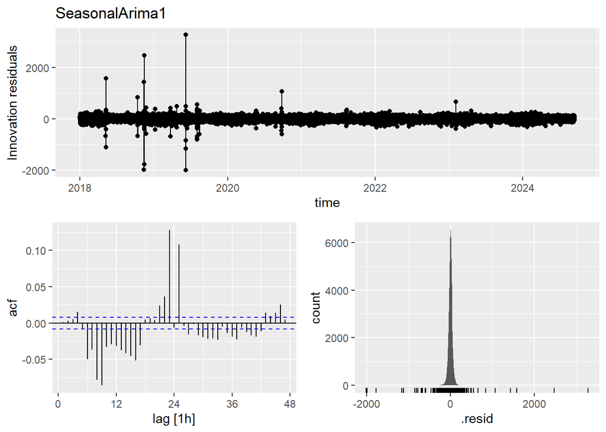

```r
# Only looking at the top 4 models, arranged by AICc

# SeasonalArima1
models %>% select(seasonalArima1) %>% gg_tsresiduals() + ggtitle("SeasonalArima1")
```

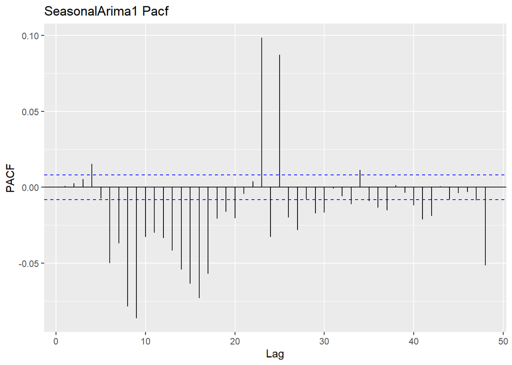

```r
models %>% select(seasonalArima1) %>% residuals() %>% ggPacf() + ggtitle("SeasonalArima1 Pacf")
```

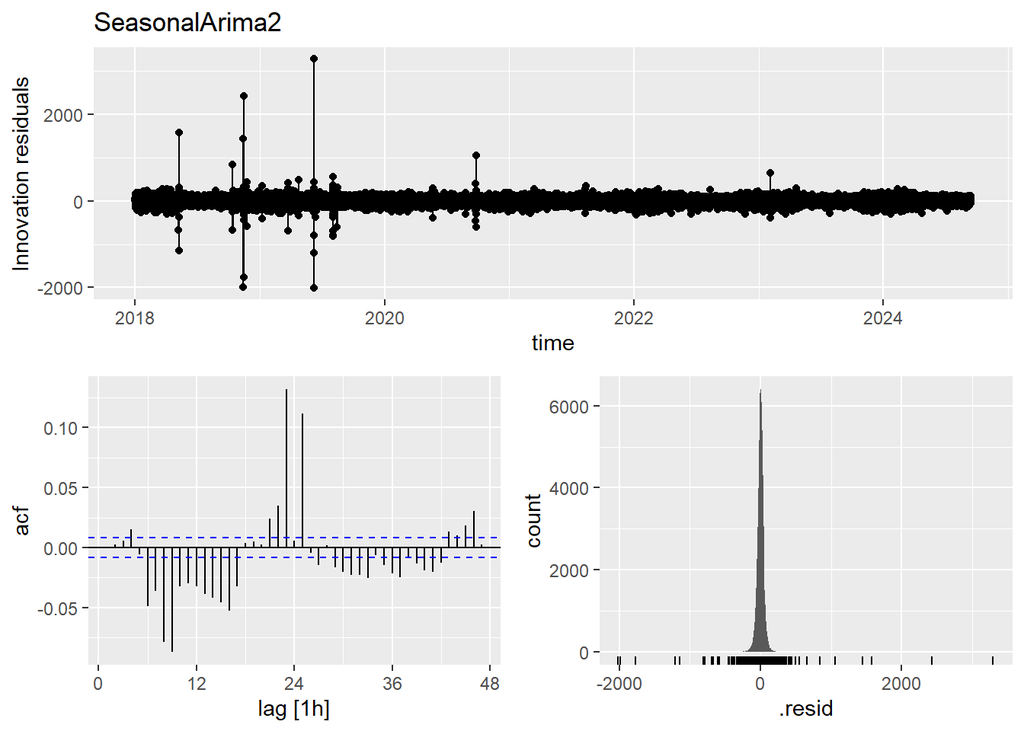

```r
# SeasonalArima2
models %>% select(seasonalArima2) %>% gg_tsresiduals() + ggtitle("SeasonalArima2")
```

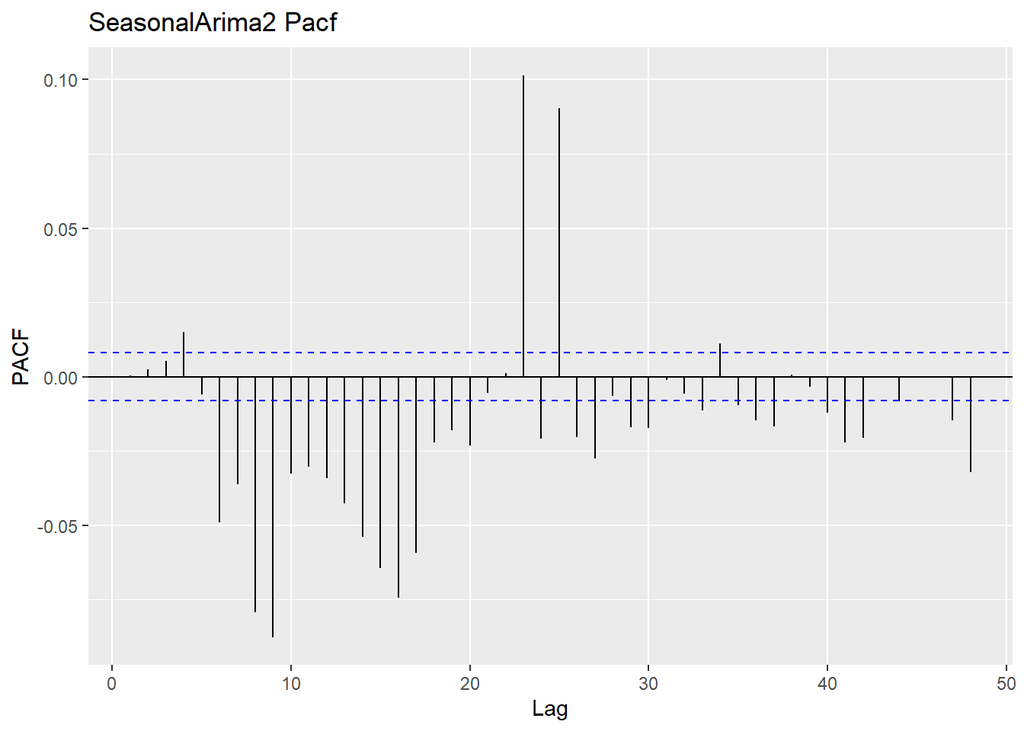

```r
models %>% select(seasonalArima2) %>% residuals() %>% ggPacf() + ggtitle("SeasonalArima2 Pacf")
```

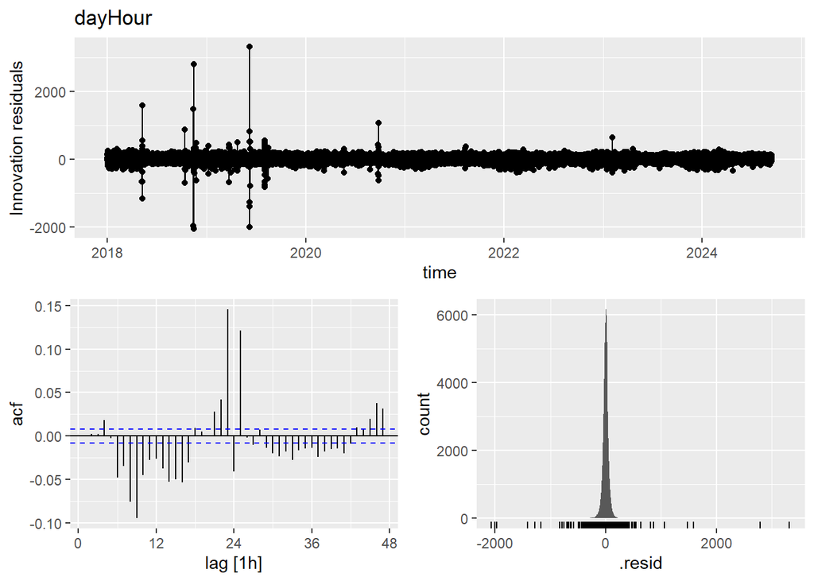

```r
# Dummy variable dayOfWeek, Hour of Day
models %>% select(dayHour) %>% gg_tsresiduals() + ggtitle("dayHour")
```

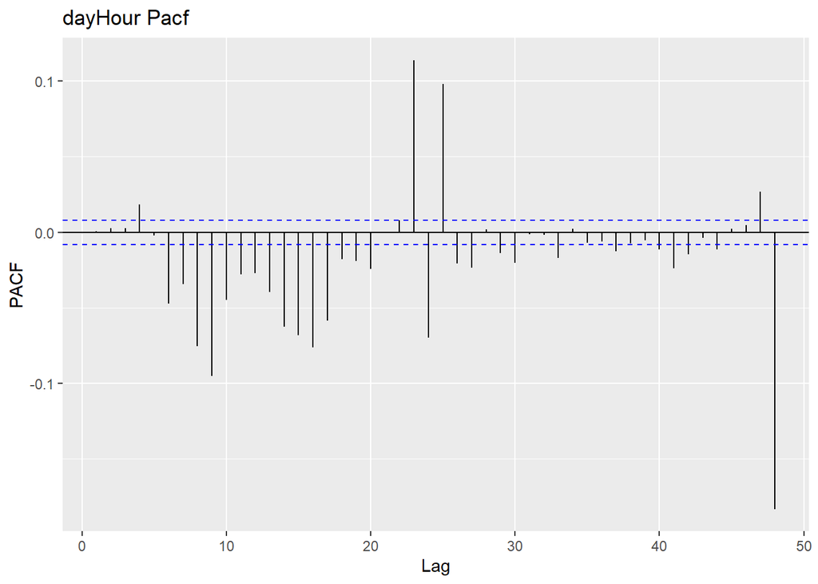

```r
models %>% select(dayHour) %>% residuals() %>% ggPacf() + ggtitle("dayHour Pacf")
```

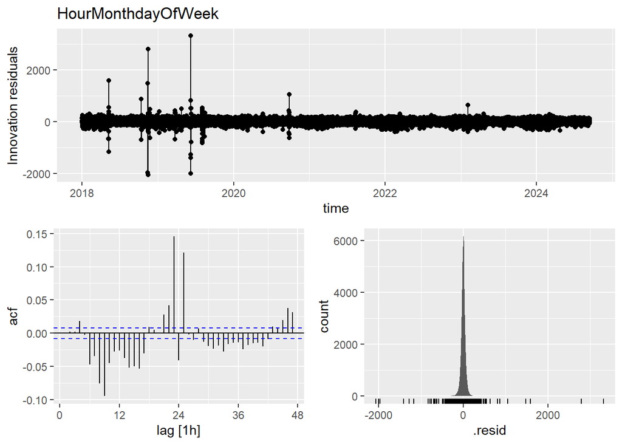

```r
# Dummy varaible, dayOfWeek, Hour of Day, and Month
models %>% select(HourMonthdayOfWeekSearch) %>% gg_tsresiduals() + ggtitle("HourMonthdayOfWeek")
```

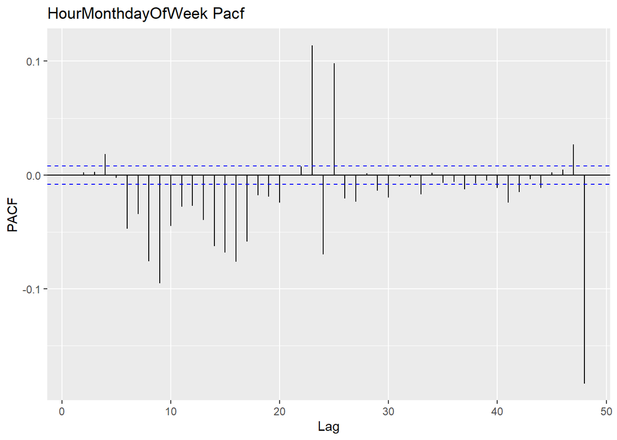

```r
models %>% select(HourMonthdayOfWeekSearch) %>% residuals() %>% ggPacf() + ggtitle("HourMonthdayOfWeek Pacf")
```

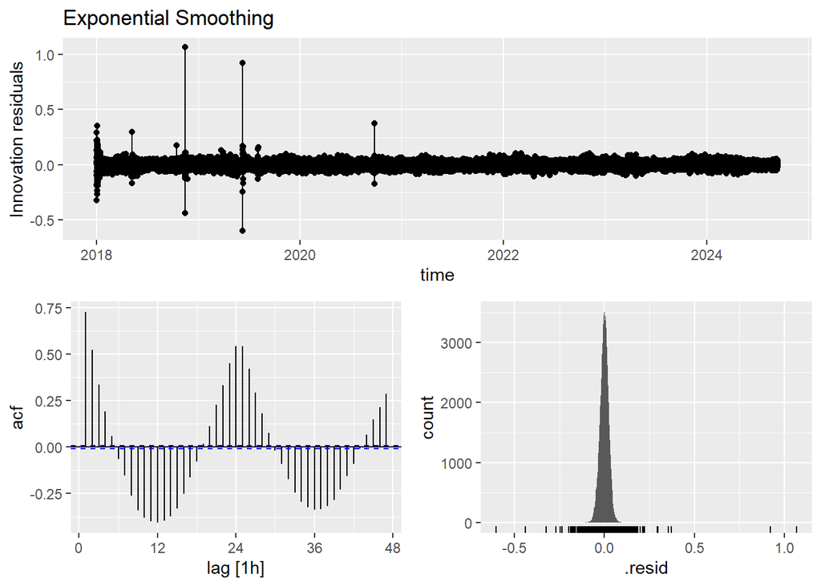

```r
# Exponential Smoothing Model
etsFit %>% select("Holt-Winters' Multiplicative") %>% gg_tsresiduals() + ggtitle("Exponential Smoothing")
```

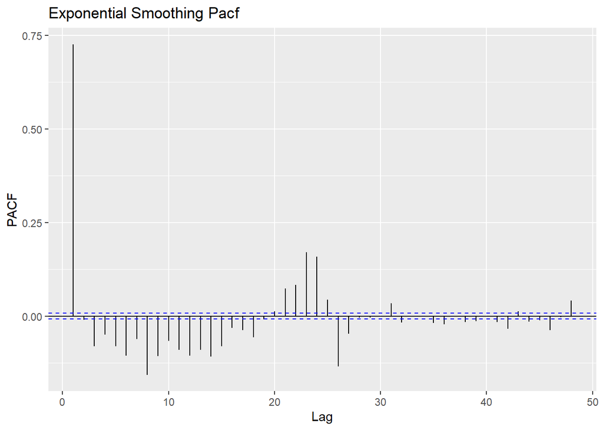

```r
etsFit %>% select("Holt-Winters' Multiplicative") %>% residuals() %>% ggPacf() + ggtitle("Exponential Smoothing Pacf")
```

I can run white noise tests with the ljung box test, but there is so much remaining autocorrelation that the p-values would be terrible. With real data like this, especially such complex data, achieving white noise is almost impossible (verified by LaBarr, but I can ask him if he wants it included)

## Model Forecasting

```r
fourierForecasts <- fourierModels %>% fabletools::forecast(new_data = energyTest)

etsForecasts <- etsFit %>% fabletools::forecast(new_data = energyTest)

seasonalForecasts <- seasonalArima %>% fabletools::forecast(h= nrow(energyTest))

dummyForecasts1 <- dummyArima1 %>% fabletools::forecast(new_data = energyTest)

dummyForecasts2 <- dummyArima2 %>% fabletools::forecast(new_data = energyTest)

# Old dummy variable models, old dataset
dummyForecasts <- dummyArima %>% fabletools::forecast(new_data = energyTest2)

# Combining the forecasts
forecasts <- bind_rows(dummyForecasts,dummyForecasts1,dummyForecasts2,fourierForecasts,etsForecasts,seasonalForecasts)
```

## MAPE and MAE

```r
accuracies <- fabletools::accuracy(forecasts,energyTest)

accuracies <- accuracies[,c(".model","MAPE","MAE")] %>% arrange(MAPE)

print(accuracies)
```

```
## # A tibble: 24 × 3
##    .model                               MAPE   MAE
##    <chr>                               <dbl> <dbl>
##  1 seasonalArima2                       3.51  139.
##  2 dayHour                              3.89  152.
##  3 HourMonthdayOfWeekSearch             3.89  152.
##  4 hour                                 4.01  156.
##  5 HourMonthSearch                      4.01  156.
##  6 seasonalArima1                       4.45  179.
##  7 Holt-Winters' Multiplicative         4.50  179.
##  8 Holt-Winters' Multiplicative Damped  4.50  180.
##  9 dayMonthWeekYear2                    4.60  195.
## 10 Holt-Winters Additive                4.63  185.
## # ℹ 14 more rows
```